# Data Visualization using ggplot2

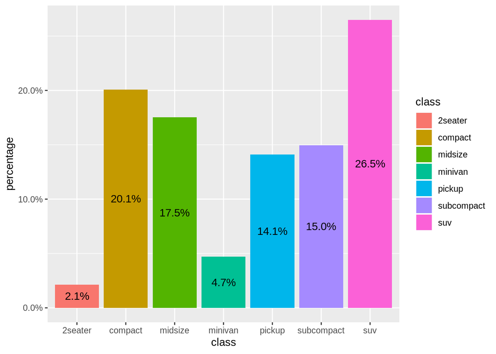

```r
ggplot(class_drive, aes(class, percentage, fill = class)) +
  geom_bar(stat = "identity") +
  geom_text(aes(label=scales::percent(percentage)), position = position_stack(vjust = .5))+
  scale_y_continuous(labels = scales::percent)
```

- We can also call stat_ functions directly to add additional layers. For example, here we create a scatter plot of highway miles for each displacement value and then use stat_summary to plot the mean highway miles at each displacement value.

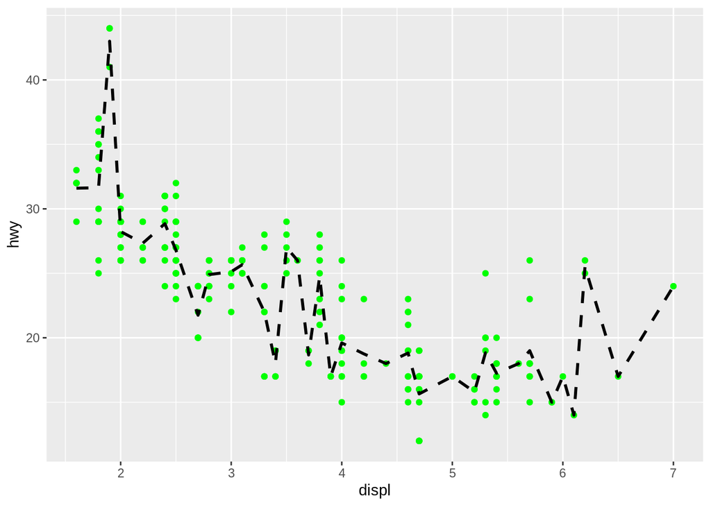

```r
ggplot(mpg, aes(displ, hwy)) +
  geom_point(color = "green") +
  stat_summary(fun.y = "mean", geom = "line", size = 1, linetype = "dashed")
```

- Multiple stats available

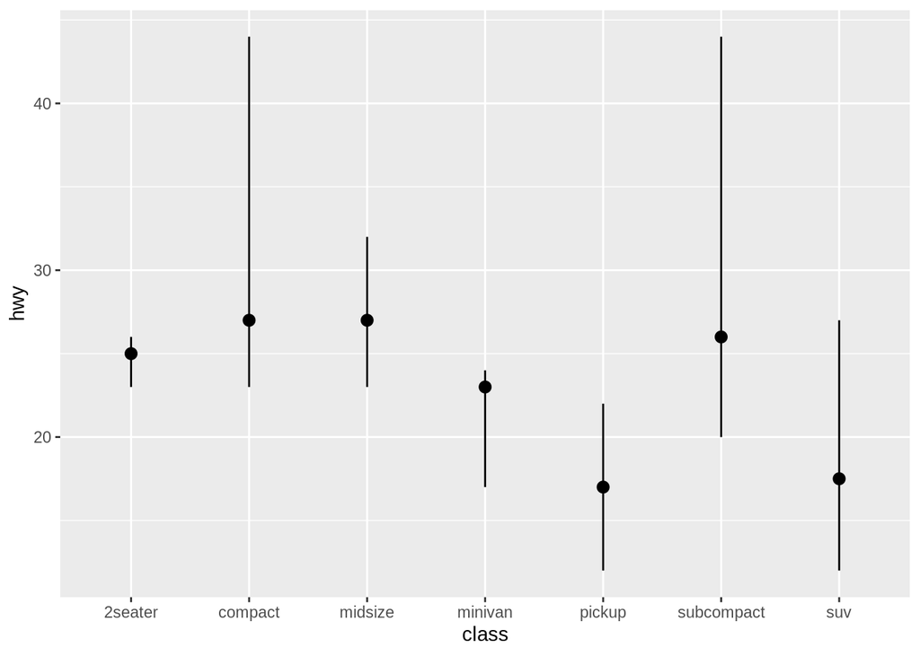

```r
ggplot(data = mpg) +
  stat_summary(mapping = aes(x = class, y = hwy),fun.ymin = min,fun.ymax = max,fun.y = median)
```

## Position Adjustments

In addition to a default statistical transformation, each geom also has a default position adjustment which specifies a set of “rules” as to how different components should be positioned relative to each other. This position is noticeable in a geom_bar if you map a different variable to the color visual characteristic:

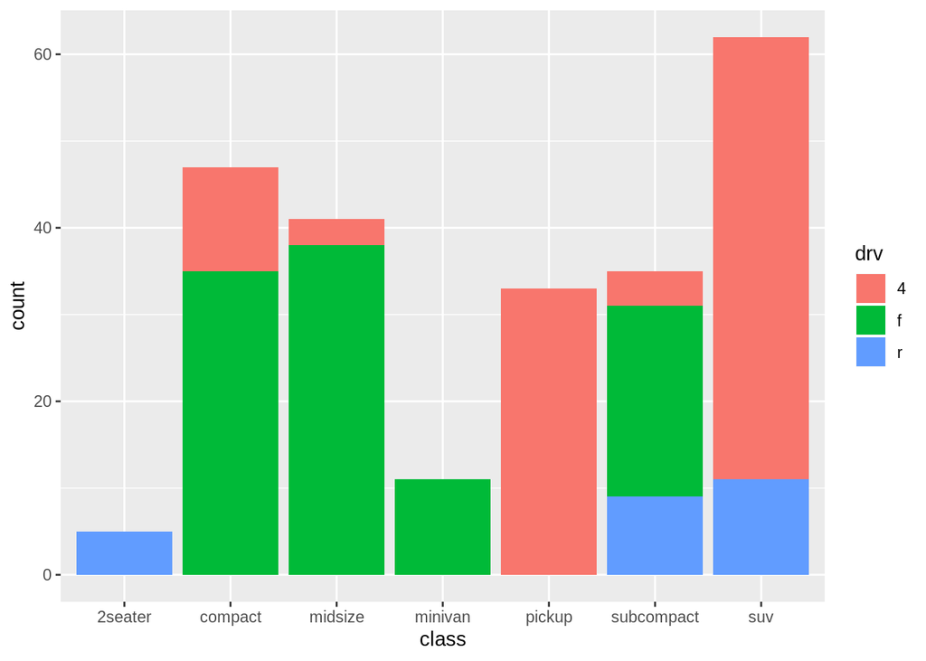

```r
# bar chart of class, colored by drive (front, rear, 4-wheel)

ggplot(mpg, aes(x = class, fill = drv)) +
  geom_bar()
```

- The geom_bar by default uses a position adjustment of “stack”, which makes each rectangle’s height proprotional to its value and stacks them on top of each other. We can use the position argument to specify what position adjustment rules to follow:

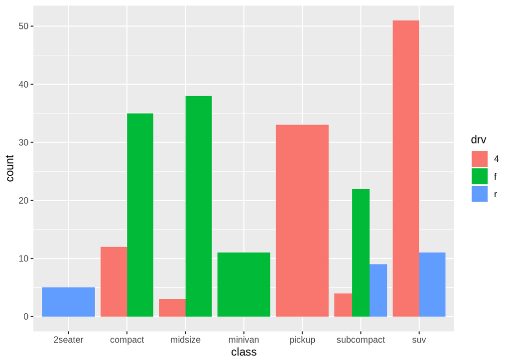

```r
# bar chart of class, colored by drive (front, rear, 4-wheel)
# position = "dodge": values next to each other
ggplot(mpg, aes(x = class, fill = drv)) +
  geom_bar(position = "dodge")
```

- Bar Chart - To visualize two categorical variables

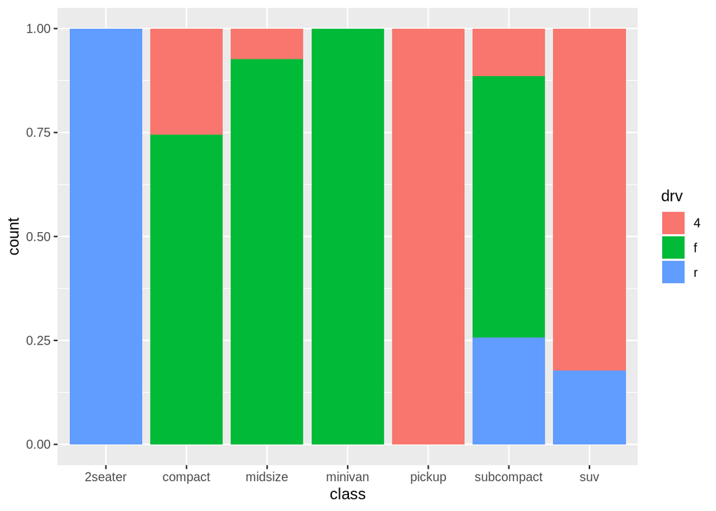

```r
# position = "fill": percentage chart
ggplot(mpg, aes(x = class, fill = drv)) +
  geom_bar(position = "fill")
```

- Avoid overplotting using jitter

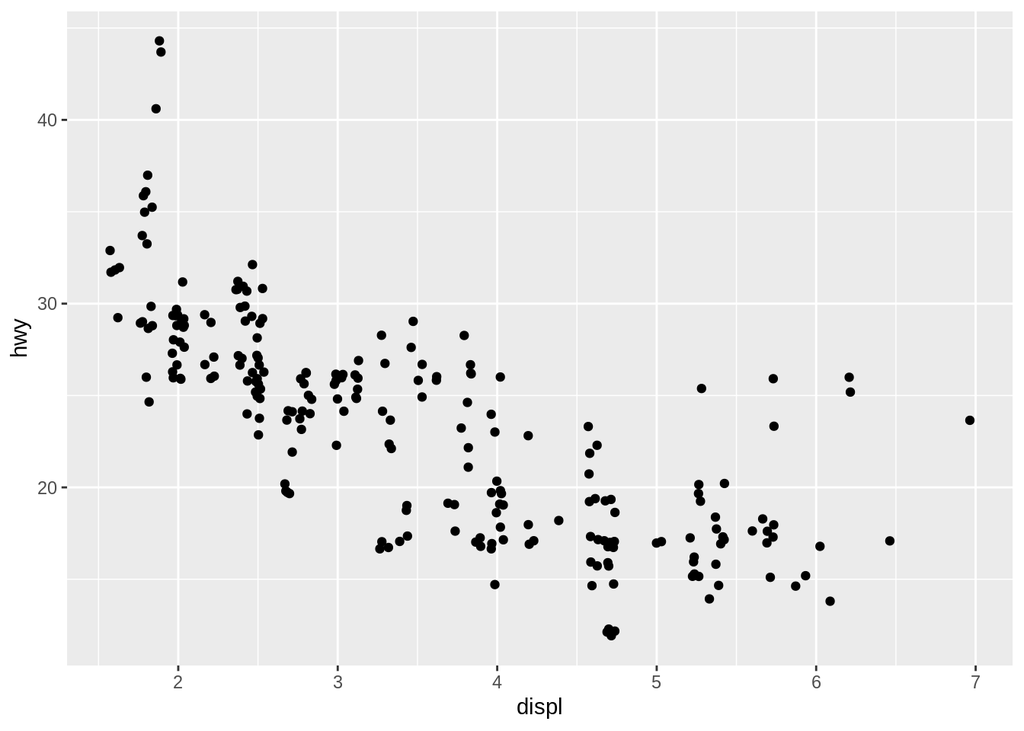

```r
ggplot(data = mpg) +
  geom_point(mapping = aes(x = displ, y = hwy), position = "jitter")
```